# RMED900 22H Exam

Group 1 : Aditi, Shwesin, Theo, Akash and Daanyaal

2022-09-16

## **Prelude**

As a group we have divided the tasks between each other. Through each others mistakes, we have learned a lot. The road is visible. Now we have produced a final recipe to tidy this specific data.

## **Packages**

- [`Reference - ways to load and install packages`](https://statsandr.com/blog/an-efficient-way-to-install-and-load-r-packages/)

```r
#install.packages(c(tidyverse, ggplot2, here, pacman))
library(tidyverse)
library(here)
library(ggplot2)
library(fs)
library(knitr)
#pacman::p_load(ggplot2, tidyverse, here, fs)
```

## **Directory and Environment**

- `Ctrl+Shift+A` to reformat code in the code chunks / R script file - `Ctrl+Shift+M` for `%>%`

```r
#getwd()  - current directory
#here()   - current directory
#setwd()  - change working directory
#ls()     - files in environment
#remove(ls()) - clears environment - OBS!
#dir()    - files in current directory
#dir_tree(here()) - draws a tree of the current directory
```

## **Reading files**

- This is the code to read files from the `working directory` and load them into the `environment`.

```r
#Make sure directory is correct
#Load file into work environment
#Separate columns using delimiter ("tab" - \t)
#Set working directory setwd() if things are not working

#using here instead of setwd()
nontidy_data <- read_delim(here("DATA", "exam_nontidy.txt"), delim = "\t")
tidy_data <- nontidy_data
join_data <- read_delim(here("DATA",  "exam_joindata.txt"), delim = "\t")
```

## **Viewing files and data sets**

```r
#view(tidy_data) #not advised for large data structures
head(tidy_data)
```

```
## # A tibble: 6 × 19
##      id date  `1.age` feature …¹ featu…² blood…³ blood…⁴ blood…⁵ blood…⁶ csf_p…⁷
##   <dbl> <chr>   <dbl> <chr>      <chr>     <dbl>   <dbl>   <dbl>   <dbl>   <dbl>
## 1     1 78-1    4     race       black      6.5       50       4     165     304
## 2     1 78-1    4     sex        female     6.5       50       4     165     304
## 3     2 78-12   1     race       black      3.70      62       5     150      NA
## 4     2 78-12   1     sex        male       3.70      62       5     150      NA
## 5     3 78-3    0.800 race       black     NA         NA      NA     183      NA
## 6     3 78-3    0.800 sex        male      NA         NA      NA     183      NA
## # … with 9 more variables: csf_rbc <dbl>, csf_wbc <dbl>, csf_neut_pct <dbl>,
## #   csf_lymph_pct <dbl>, gram <dbl>, csf_cult <dbl>, blood_cult <dbl>,
## #   abm <dbl>, csf_mono_cnt <dbl>, and abbreviated variable names
## #   ¹`feature type`, ²feature_value, ³blood_wbc, ⁴blood_neut_pct,
## #   ⁵blood_band_pct, ⁶blood_gluc, ⁷csf_prot
```

```r
#glimpse(tidy_data)
```

## **Summary statistics before tidying the data**

```r
#Provides summary statistics - missing, complete, n and sd
#<https://www.rdocumentation.org/packages/skimr/versions/2.1.4>
skimr::skim(tidy_data) %>%
  select(skim_type, skim_variable, numeric.mean, numeric.sd, numeric.p50, n_missing )
```

Data summary

| Name | tidy_data |
| --- | --- |
| Number of rows | 1162 |
| Number of columns | 19 |
| _______________________ |  |
| Column type frequency: |  |
| character | 3 |
| numeric | 16 |
| ________________________ |  |
| Group variables | None |

**Variable type: character**

| skim_variable | n_missing |
| --- | --- |
| date | 142 |
| feature type | 0 |
| feature_value | 0 |

**Variable type: numeric**

| skim_variable | n_missing | mean | sd | p50 |
| --- | --- | --- | --- | --- |
| id | 0 | 291.00 | 167.79 | 291.0 |
| 1.age | 162 | 13.66 | 19.68 | 3.0 |
| blood_wbc | 282 | 13.86 | 8.53 | 12.0 |
| blood_neut_pct | 292 | 63.30 | 19.62 | 67.0 |
| blood_band_pct | 306 | 6.68 | 10.63 | 2.0 |
| blood_gluc | 516 | 138.04 | 54.38 | 125.0 |
| csf_prot | 498 | 155.72 | 215.30 | 83.0 |
| csf_rbc | 542 | 1557.69 | 6655.41 | 27.5 |
| csf_wbc | 202 | 2492.90 | 7451.53 | 336.5 |
| csf_neut_pct | 264 | 59.74 | 36.06 | 75.0 |
| csf_lymph_pct | 324 | 41.12 | 44.04 | 25.0 |
| gram | 626 | 1.63 | 1.80 | 1.0 |
| csf_cult | 614 | 1.39 | 1.68 | 1.0 |
| blood_cult | 868 | 1.10 | 1.73 | 1.0 |
| abm | 160 | 0.43 | 0.50 | 0.0 |
| csf_mono_cnt | 338 | 996.32 | 9012.86 | 0.0 |

## **Missing values**

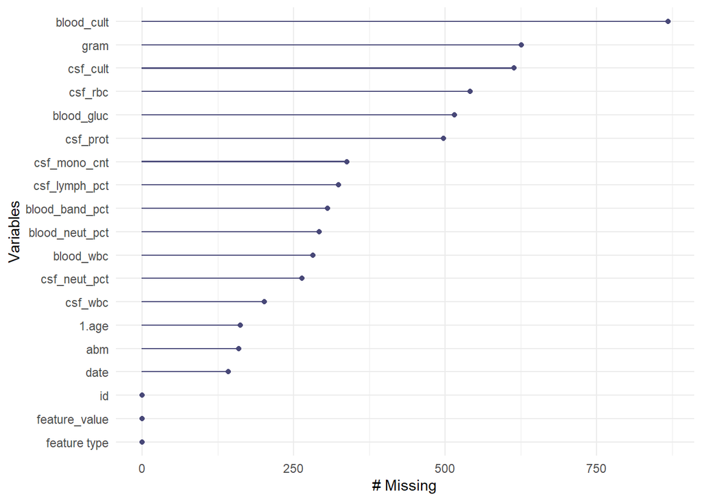

```r
#Graph showing frequency of missing for each variable
naniar::gg_miss_var((tidy_data))
```

## **Column names**

```r
#column names
colnames(tidy_data)
```

```
##  [1] "id"             "date"           "1.age"          "feature type"
##  [5] "feature_value"  "blood_wbc"      "blood_neut_pct" "blood_band_pct"
##  [9] "blood_gluc"     "csf_prot"       "csf_rbc"        "csf_wbc"
## [13] "csf_neut_pct"   "csf_lymph_pct"  "gram"           "csf_cult"
## [17] "blood_cult"     "abm"            "csf_mono_cnt"
```

# **Tidying the data**

[figure not shown]

```r
#The Pipe setup of multiple tidy mutations and transformation
#----------------Will yield to the tidiest data -------------------#


tidy_data <- tidy_data %>%   #Assign our transformed data to object
  pivot_wider(names_from = `feature type`,
              values_from = feature_value, ) %>%  #Eradicating duplicates by pivot
  rename(age = `1.age`) %>%        #Renaming unfortunate column name
  separate(date,                  #Better visualization be separating column
           into = c("year", "month"),
           sep = "-") %>%
  mutate(age = as.numeric(age)) %>%         #Defining column content as numerical
  mutate(across(.cols = age, ~ round(., digits = 3))) %>% #Keeping to three decimal across all columns
  mutate(race =                         #Abbreviating the content in column
           case_when(
             race == "black" ~ "B",
             race == "white" ~ "W",
             race == "none" ~ NA_character_
           )) %>%
  mutate(sex =
           case_when(
             sex == "female" ~ "0",
             sex == "male" ~ "1",
             sex == "none" ~ NA_character_
           )) %>%
  mutate(sex = as.factor(sex)) %>%         #Defining column as categorical
  mutate(blood_neut_pct = if_else(blood_neut_pct <= 35, "Low", "High")) %>%
  mutate(blood_cult = 100 * blood_cult / max(blood_cult, na.rm = TRUE)) %>%
  mutate(blood_cult = round(blood_cult, digits = 0)) %>% #Keeping to nearest whole number
  mutate(blood_wbc = round(blood_wbc, digits = 1)) %>%     #keeping 1 decimal
  mutate(age_agm = age * abm) %>%   #numeric column showing multiplication of age and abm
  subset(select = -c(gram, month)) %>%  #Removing excessive column
  select(id,
         age,
         sex,
         race,
         starts_with("csf"),
         starts_with("blood"),
         everything()) %>% #Another way to keep only the columns you want
  full_join(join_data, by = ("id")) %>% #joining the join data file to the mutated tidy_data
  arrange(id) #ordering ID in ascending


# Converts continuous "numeric" into categorical "factor" data
# This methods allows the conversion of several variables into once
factor_cols <-  c("sex", "year", "abm", "race", "blood_neut_pct")
tidy_data[, factor_cols] <-
  lapply(tidy_data[, factor_cols] , factor)
```

## **Saving files**

```r
#Check path/ directory before saving
#write_csv(tidy_data, file = "exam_tidy.csv")
```

## **After cleaning, the data looks better**

The variables `"blood_cult"` and `"csf_cult"` have the highest proportion of missing. The data set consists of 20 columns and 581 rows.

```r
skimr::skim(tidy_data) %>%  #Tidyverse way
    select(skim_type, skim_variable, numeric.mean, numeric.sd, numeric.p50, n_missing )
```

Data summary

| Name | tidy_data |
| --- | --- |
| Number of rows | 581 |
| Number of columns | 20 |
| _______________________ |  |
| Column type frequency: |  |
| factor | 5 |
| numeric | 15 |
| ________________________ |  |
| Group variables | None |

**Variable type: factor**

| skim_variable | n_missing |
| --- | --- |
| sex | 81 |
| race | 85 |
| blood_neut_pct | 146 |
| year | 71 |
| abm | 80 |

**Variable type: numeric**

| skim_variable | n_missing | mean | sd | p50 |
| --- | --- | --- | --- | --- |
| id | 0 | 291.00 | 167.86 | 291.0 |
| age | 81 | 13.66 | 19.69 | 3.0 |
| csf_prot | 249 | 155.72 | 215.46 | 83.0 |
| csf_rbc | 271 | 1557.69 | 6660.79 | 27.5 |
| csf_wbc | 101 | 2492.90 | 7455.42 | 336.5 |
| csf_neut_pct | 132 | 59.74 | 36.08 | 75.0 |
| csf_lymph_pct | 162 | 41.12 | 44.06 | 25.0 |
| csf_cult | 307 | 1.39 | 1.69 | 1.0 |
| csf_mono_cnt | 169 | 996.32 | 9018.34 | 0.0 |
| blood_wbc | 141 | 13.86 | 8.53 | 12.0 |
| blood_band_pct | 153 | 6.68 | 10.63 | 2.0 |
| blood_gluc | 258 | 138.04 | 54.42 | 125.0 |
| blood_cult | 434 | 9.98 | 15.77 | 9.0 |
| age_agm | 161 | 6.55 | 17.73 | 0.1 |
| csf_gluc | 129 | 58.32 | 34.03 | 61.0 |

```r
#summary(tidy_data) #R base function
```

## **How to count? AKA the frequency**

- This is how we calculated the number of individuals regardless of meningitis status by `race` and `sex.`

```r
#frequency/count for each subgroup
tidy_data %>%
  group_by(race, sex) %>%
  filter(!is.na(race) & !is.na(sex)) %>%
  count() %>%
  rename(total = n)
```

```
## # A tibble: 4 × 3
## # Groups:   race, sex [4]
##   race  sex   total
##   <fct> <fct> <int>
## 1 B     0       133
## 2 B     1       153
## 3 W     0        86
## 4 W     1       124
```

```r
#Table in R base function format
#table(tidy_data$race, tidy_data$sex) %>% head()
```

## **Summary statistics - `WBC (white blood cells) in blood`**

- Here are the summary statistics for `"blood_wbc"`
  - Maximum
  - Mean
  - Minimum
  - Standard deviation

### … by sex

```r
# Mean/Min/Max/SD of white blood count in blood (blood_wbc) by sex and race

#blood_wbc_sex <-
tidy_data %>%
  group_by(sex) %>%
  filter(!is.na(sex)) %>%
  summarise(
    max_blood_wbc = max(blood_wbc, na.rm = T),
    min_blood_wbc = min(blood_wbc, na.rm = T),
    mean_blood_wbc = mean(blood_wbc, na.rm = T),
    sd_blood_wbc = sd(blood_wbc, na.rm = T)
  )
```

```
## # A tibble: 2 × 5
##   sex   max_blood_wbc min_blood_wbc mean_blood_wbc sd_blood_wbc
##   <fct>         <dbl>         <dbl>          <dbl>        <dbl>
## 1 0              72.4           0.6           14.5         9.58
## 2 1              53.5           1.7           13.3         7.54
```

### … by race

```r
#blood_wbc_race <-
tidy_data %>%
  group_by(race) %>%
  filter(!is.na(race)) %>%
  summarise(
    max_blood_wbc = max(blood_wbc, na.rm = T),
    min_blood_wbc = min(blood_wbc, na.rm = T),
    mean_blood_wbc = mean(blood_wbc, na.rm = T),
    sd_blood_wbc = sd(blood_wbc, na.rm = T)
  )
```

```
## # A tibble: 2 × 5
##   race  max_blood_wbc min_blood_wbc mean_blood_wbc sd_blood_wbc
##   <fct>         <dbl>         <dbl>          <dbl>        <dbl>
## 1 B              72.4           1.7           13.8         8.92
## 2 W              53.5           0.6           14.0         8.04
```

### … by sex and race

```r
#blood_wbc_race_sex <-
tidy_data %>%
  filter(!is.na(race) &
           !is.na(sex)) %>% #removing cases with missing data for gender and sex
  group_by(race, sex) %>%
  summarise(
    max_blood_wbc = max(blood_wbc, na.rm = T),
    min_blood_wbc = min(blood_wbc, na.rm = T),
    mean_blood_wbc = mean(blood_wbc, na.rm = T),
    sd_blood_wbc = sd(blood_wbc, na.rm = T),
    .groups = 'drop'
  ) # Adding this to remove the warning : https://stackoverflow.com/questions/62140483/how-to-interpret-dplyr-message-summarise-regrouping-output-by-x-override
```

```
## # A tibble: 4 × 6
##   race  sex   max_blood_wbc min_blood_wbc mean_blood_wbc sd_blood_wbc
##   <fct> <fct>         <dbl>         <dbl>          <dbl>        <dbl>
## 1 B     0              72.4           3.5           14.7        10.2
## 2 B     1              52.5           1.7           12.9         7.54
## 3 W     0              47.5           0.6           14.1         8.74
## 4 W     1              53.5           1.7           13.9         7.55
```

## **More data analysis –> Summary statistics - `Protein in CSF`**

### … if blood culture is absent

```r
# Mean/Min/Max/SD of csf_prot (Protein in CSF) for people with :

#   blood_cult == 0
tidy_data %>%
  filter(blood_cult == 0) %>%
  summarise(
    max_csf_prot = max(csf_prot, na.rm = T),
    min_csf_prot = min(csf_prot, na.rm = T),
    mean_csf_prot = mean(csf_prot, na.rm = T),
    sd_csf_prot = sd(csf_prot, na.rm = T)
  )
```

```
## # A tibble: 1 × 4
##   max_csf_prot min_csf_prot mean_csf_prot sd_csf_prot
##          <dbl>        <dbl>         <dbl>       <dbl>
## 1          680           18          176.        153.
```

### … in females

```r
#   females
tidy_data %>%
  filter(sex == 0) %>%
  summarise(
    max_csf_prot = max(csf_prot, na.rm = T),
    min_csf_prot = min(csf_prot, na.rm = T),
    mean_csf_prot = mean(csf_prot, na.rm = T),
    sd_csf_prot = sd(csf_prot, na.rm = T)
  )
```

```
## # A tibble: 1 × 4
##   max_csf_prot min_csf_prot mean_csf_prot sd_csf_prot
##          <dbl>        <dbl>         <dbl>       <dbl>
## 1         1488            1          146.        208.
```

### … in individuals with the race black and blood glucose higher than 120

```r
#   race black and blood_gluc higher than 120
tidy_data %>%
  filter(blood_gluc >= 120 & race == "B") %>%
  summarise(
    max_csf_prot = max(csf_prot, na.rm = T),
    min_csf_prot = min(csf_prot, na.rm = T),
    mean_csf_prot = mean(csf_prot, na.rm = T),
    sd_csf_prot = sd(csf_prot, na.rm = T)
  )
```

```
## # A tibble: 1 × 4
##   max_csf_prot min_csf_prot mean_csf_prot sd_csf_prot
##          <dbl>        <dbl>         <dbl>       <dbl>
## 1         1740            3          186.        239.
```

### … in individuals older than 45 years of age

```r
#   persons older than 45
#Since there is repetition, we decided to create a function to fo this job for us.
data_summary <- function(y) {
  max_ <- max(y, na.rm = T)
  min_ <- min(y, na.rm = T)
  mean_ <- mean(y, na.rm = T)
  sd_ <- sd(y, na.rm = T)
  data_ <- c(max_, min_, mean_, sd_)
  col_ <- c("Maximum", "Minimum", "Mean", "SD")
  df_ <- tibble(col_, data_)
  return(df_)
}

#Although smart, it doesn't seem to work with the pipes.
#Therefore, we created a new data set with the specific filters and ran that as a argument of the function.
tidy_data_age_45 <- tidy_data %>%
  filter(age >= 45)
data_summary(tidy_data_age_45$csf_prot)
```

```
## # A tibble: 4 × 2
##   col_    data_
##   <chr>   <dbl>
## 1 Maximum 1152
## 2 Minimum   16
## 3 Mean     244.
## 4 SD       252.
```

## **Even moooorrrre data analysis –> Correlations**

To identify correlated variables, we identified and dropped variables with the highest amount of missing data.

Using the library `corrplot`, we plotted the **correlations** obtained using the function `cor` to understand how the variables are correlated to each other.

```r
#    - Are there any correlated measurements?

# We decided to plot a correlation matrix

#https://cran.r-project.org/web/packages/corrplot/vignettes/corrplot-intro.html

df <- select(tidy_data,-("id")) #removing ID
df <-  select(df,-("blood_cult")) #removing "blood_cult" since it has a lot of missing values
df <- df[sapply(df, is.numeric)] #making all variables numeric
df <-  df[complete.cases(df), ] #ensuring only those rows with complete information in all columns are included
cor(df, method = "pearson" , use = "complete.obs") #A correlation matrix for all variables
```

```
##                        age    csf_prot     csf_rbc     csf_wbc csf_neut_pct
## age             1.00000000  0.24215225  0.17236963  0.04437760   0.03847003
## csf_prot        0.24215225  1.00000000  0.02574575  0.10684166   0.18012011
## csf_rbc         0.17236963  0.02574575  1.00000000  0.86449819   0.15734277
## csf_wbc         0.04437760  0.10684166  0.86449819  1.00000000   0.24503513
## csf_neut_pct    0.03847003  0.18012011  0.15734277  0.24503513   1.00000000
## csf_lymph_pct  -0.09976538 -0.12144576 -0.08168867 -0.12012095  -0.41038994
## csf_cult        0.36451459  0.12785083  0.03622271 -0.04420181   0.10333305
## csf_mono_cnt   -0.10841115 -0.11081967 -0.04813236 -0.04831976  -0.43532746
## blood_wbc      -0.02508212  0.34915703  0.07835625  0.28025725   0.07731409
## blood_band_pct -0.24551703  0.08594212 -0.08008726 -0.03462894   0.16188317
## blood_gluc      0.30533642  0.05493997 -0.06656661 -0.04010013   0.09251958
## age_agm         0.99627401  0.25262049  0.17606266  0.05038876   0.07460957
## csf_gluc        0.04669904 -0.19383673 -0.11652823 -0.14567720  -0.13152127
##                csf_lymph_pct    csf_cult csf_mono_cnt    blood_wbc
## age             -0.099765375  0.36451459 -0.108411149 -0.025082118
## csf_prot        -0.121445762  0.12785083 -0.110819667  0.349157025
## csf_rbc         -0.081688668  0.03622271 -0.048132364  0.078356248
## csf_wbc         -0.120120954 -0.04420181 -0.048319763  0.280257252
## csf_neut_pct    -0.410389941  0.10333305 -0.435327459  0.077314091
## csf_lymph_pct    1.000000000 -0.09060821 -0.022950478  0.025143015
## csf_cult        -0.090608206  1.00000000 -0.168090821 -0.069940458
## csf_mono_cnt    -0.022950478 -0.16809082  1.000000000  0.008834787
## blood_wbc        0.025143015 -0.06994046  0.008834787  1.000000000
## blood_band_pct  -0.012311291 -0.23101102 -0.108336920 -0.091789294
## blood_gluc      -0.165410060  0.08324772 -0.069832285 -0.039043275
## age_agm         -0.104656113  0.37898880 -0.131171531 -0.009485842
## csf_gluc        -0.004756359  0.19372260  0.106400583 -0.089261902
##                blood_band_pct   blood_gluc      age_agm     csf_gluc
## age              -0.245517032  0.305336416  0.996274014  0.046699043
## csf_prot          0.085942123  0.054939973  0.252620492 -0.193836731
## csf_rbc          -0.080087260 -0.066566610  0.176062664 -0.116528232
## csf_wbc          -0.034628937 -0.040100133  0.050388762 -0.145677202
## csf_neut_pct      0.161883171  0.092519577  0.074609571 -0.131521265
## csf_lymph_pct    -0.012311291 -0.165410060 -0.104656113 -0.004756359
## csf_cult         -0.231011019  0.083247720  0.378988805  0.193722600
## csf_mono_cnt     -0.108336920 -0.069832285 -0.131171531  0.106400583
## blood_wbc        -0.091789294 -0.039043275 -0.009485842 -0.089261902
## blood_band_pct    1.000000000 -0.003597078 -0.232019404 -0.077493592
## blood_gluc       -0.003597078  1.000000000  0.316117005  0.510206300
## age_agm          -0.232019404  0.316117005  1.000000000  0.032849057
## csf_gluc         -0.077493592  0.510206300  0.032849057  1.000000000
```

## **And now, our Correlation plot `corrplot`**

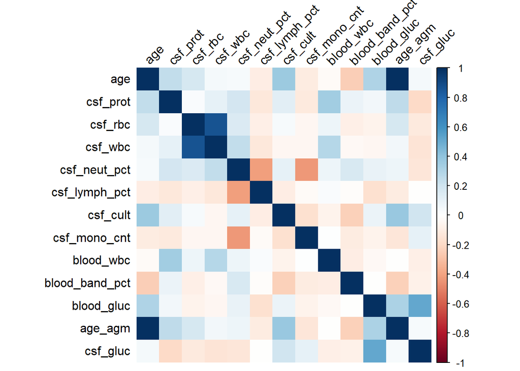

```r
#install.packages("corrplot")
library(corrplot) #can help graphically visualize the correlation plots
corrplot(
  cor(df),
  method = "shade",
  shade.col = NA,
  tl.col = "black",
  tl.srt = 45
)
```

## **Summary statistics - `Blood glucose levels`**

### … by sex

The average blood glucose level is higher in women compared to men.

```r
#    - Does the glucose level in blood depend on sex?

tidy_data %>%
  drop_na(sex,
          blood_gluc) %>% #remove missing values to make less messy table
  group_by(sex) %>% #Now select this as the group we check glucose for
  summarize(
    min_blood_gluc = min(blood_gluc),
    mean_blood_gluc = mean(blood_gluc),
    max_blood_gluc = max(blood_gluc),
    sd_blood_gluc = sd(blood_gluc)
  ) %>%
  arrange()
```

```
## # A tibble: 2 × 5
##   sex   min_blood_gluc mean_blood_gluc max_blood_gluc sd_blood_gluc
##   <fct>          <dbl>           <dbl>          <dbl>         <dbl>
## 1 0                 35            143.            410          62.5
## 2 1                  1            134.            380          46.7
```

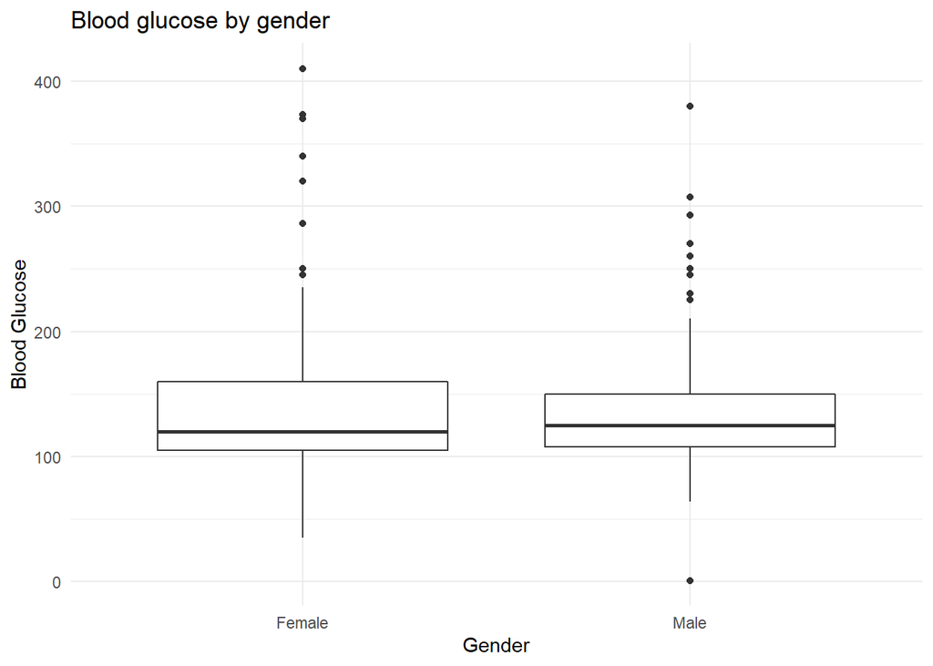

```r
#The average blood glucose level in women is higher than in men


#Graph - Boxplot
tidy_data %>%
  drop_na(sex) %>% #removed missing "sex"
  ggplot(aes(x = as.factor(sex), #to make "sex" categorical
             y = blood_gluc)) +
  geom_boxplot() +
  scale_x_discrete(name = "Gender", labels = c("Female", "Male")) +
  scale_y_continuous(name = "Blood Glucose") +
  theme_minimal() +
  labs(title = "Blood glucose by gender")
```

### … by race

- ... but this difference is not evident among the different races.

```r
#    - Does the glucose level in blood depend on race?

tidy_data %>%
  drop_na(race,
          blood_gluc) %>%
  group_by(race) %>%
  summarize(
    min_blood_gluc = min(blood_gluc),
    mean_blood_gluc = mean(blood_gluc),
    max_blood_gluc = max(blood_gluc),
    sd_blood_gluc = sd(blood_gluc)
  ) %>%
  arrange()
```

```
## # A tibble: 2 × 5
##   race  min_blood_gluc mean_blood_gluc max_blood_gluc sd_blood_gluc
##   <fct>          <dbl>           <dbl>          <dbl>         <dbl>
## 1 B                 35            138.            380          51.9
## 2 W                  1            138.            410          58.4
```

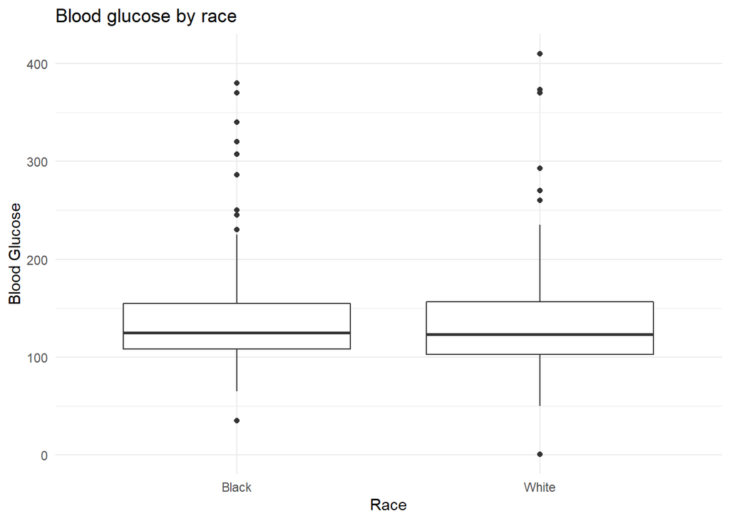

```r
#The average blood glucose level among blacks and whites is similar


#Graph - Boxplot
tidy_data %>%
  drop_na(race) %>%
  ggplot(aes(x = as.factor(race),
             y = blood_gluc)) +
  geom_boxplot() +
  scale_x_discrete(name = "Race", labels = c("Black", "White")) +
  scale_y_continuous(name = "Blood Glucose") +
  theme_minimal() +
  labs(title = "Blood glucose by race")
```

## **Summary statistics - `CSF glucose levels`**

### … by race and sex

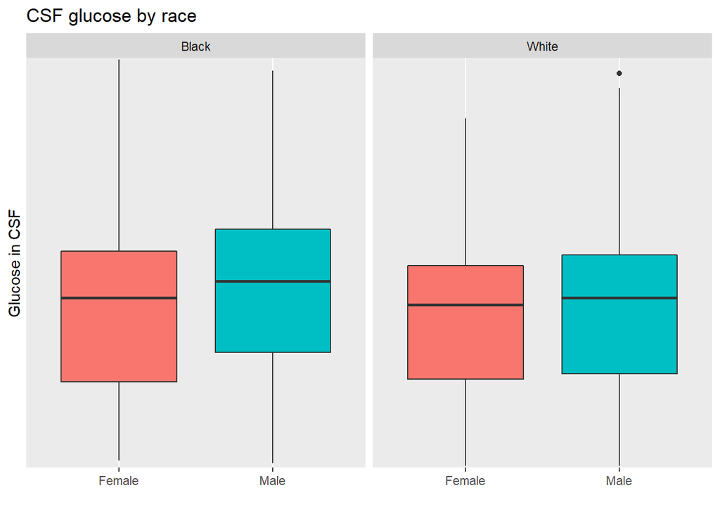

```r
#    - Does the glucose level in CSF (cerebrospinal fluid) depend on sex?
# -Does the glucose level in CSF (cerebrospinal fluid) depend on race ?

Gluc_CSF <- tidy_data %>%
  drop_na(race, sex) %>%
  ggplot(aes(x = as.factor(sex),
             y = csf_gluc, fill = sex)) +
  geom_boxplot() +
  scale_x_discrete(name = "", labels = c("Female", "Male")) +
  scale_y_discrete(name = "Glucose in CSF") +
  theme(legend.position = "none")

#Graphing the difference between race and gender on CSF glucose using FACET!
#https://r-graph-gallery.com/264-control-ggplot2-boxplot-colors.html
new_labels <- c("B" = "Black", "W" = "White")
Gluc_CSF + facet_grid(cols = vars(race),
                      labeller = labeller(race = new_labels)) +
  labs(title = "CSF glucose by race")
```

```r
#Does the glucose level in CSF (cerebrospinal fluid) depend on race?
csf_gluc_race_grouped <- tidy_data %>%
  filter(race == "B" | race == "W") %>%
  group_by(race)
#calculate sum of csf_gluc per race
csf_gluc_race_summary <- csf_gluc_race_grouped %>%
  summarise(sum = sum(csf_gluc, na.rm = TRUE))
csf_gluc_race_summary
```

```
## # A tibble: 2 × 2
##   race     sum
##   <fct>  <dbl>
## 1 B     15662.
## 2 W     10461
```

## **Does the occurrence of the diseases differ by sex?**

```r
#   - Is there a difference in the occurrence of the disease by sex?
tidy_data_4chisq <- tidy_data %>%
  mutate(sex = as.numeric(sex)) %>%
  #mutating, so that it is same type as abm
  #(R doesn't think like a statistician, so both can be numerical)
  select(abm, sex) #select the variable
#In this test, make sure both variables are same class/type
chisq.test(tidy_data_4chisq$abm, tidy_data_4chisq$sex)
```

```
##
##  Pearson's Chi-squared test with Yates' continuity correction
##
## data:  tidy_data_4chisq$abm and tidy_data_4chisq$sex
## X-squared = 1.3183, df = 1, p-value = 0.2509
```

```r
#In this case, the test is not significant.
```

## **Time trend of meningitis**

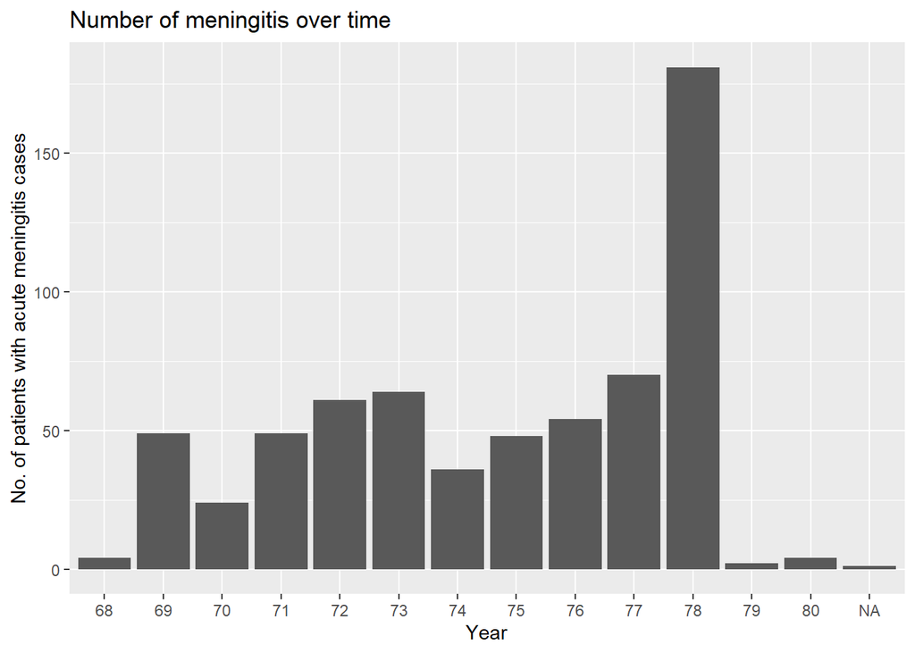

```r
#   - Is there a time trend in the occurrence of the disease?

tidy_data %>%
group_by(year) %>%
  mutate(abm = as.numeric(abm)) %>%
  filter(!is.na(year)) %>%
  filter(!is.na(abm)) %>%
  #mutate abm into numeric since a factor cannot be summarized
  #doesn't understand statistics
  summarise(sum_abm = sum(abm, na.rm = T)) %>%
  #  table() #For drawing a cross-tab
  ggplot(aes(x = as.factor(year),
             y = sum_abm)) +
  geom_col() +
  scale_x_discrete(name = "Year") +
  scale_y_continuous(name = "No. of patients with acute meningitis cases") +
  theme(legend.position = "none") +
  labs(title = "Number of meningitis over time")
```

```r
#Trying linear regression on frequency per year
time_trend <-
  tidy_data %>%
  group_by(year) %>%
  mutate(abm = as.numeric(abm)) %>%
  mutate(year = as.numeric(year)) %>%

  filter(!is.na(year)) %>%
  summarise(sum_abm = sum(abm, na.rm = T)) %>%
  lm(sum_abm ~ year, data = .) %>%
  broom::tidy()
head(time_trend)
```

```
## # A tibble: 2 × 5
##   term        estimate std.error statistic p.value
##   <chr>          <dbl>     <dbl>     <dbl>   <dbl>
## 1 (Intercept)   42.6       27.0      1.58    0.141
## 2 year           0.481      3.17     0.152   0.882
```

## **Does the occurrence of the diseases differ by age or race?**

Most of the cases of the disease occur in younger age groups, with a slight hump also visible at age 60. There is a higher number of black children and white adults that are affected by the disease.

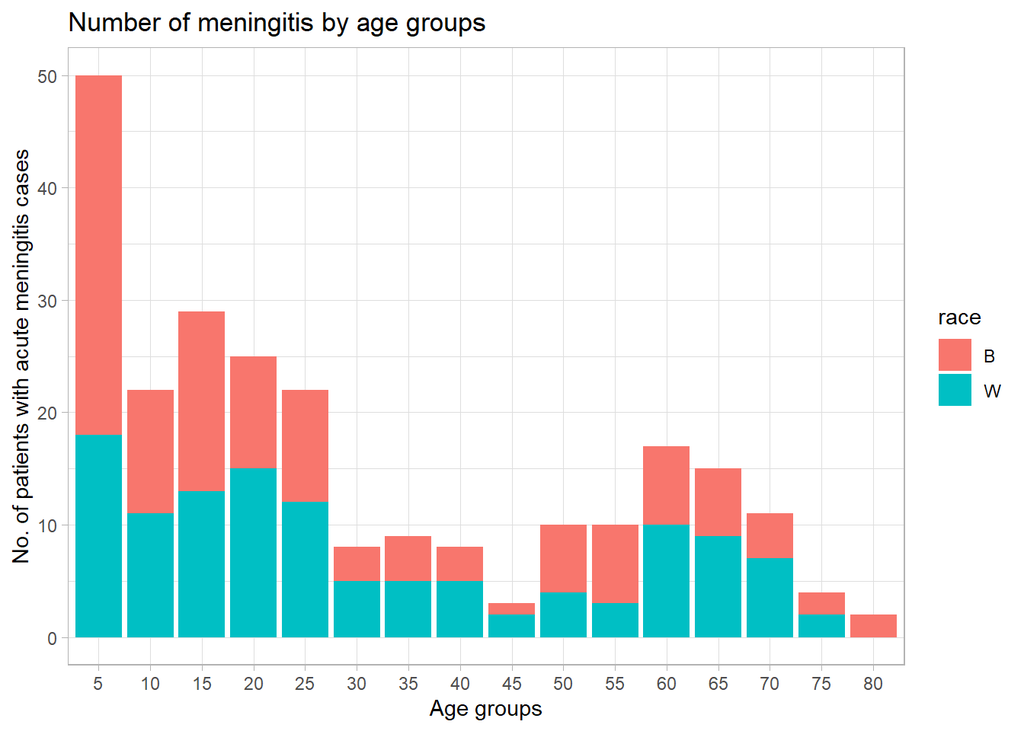

```r
#    - Does the occurrence of the disease depend on age?
#    - Is there a difference in the occurrence of the disease by race?

#https://www.statology.org/r-create-categorical-variable-from-continuous/

tidy_data <- tidy_data %>%
  mutate(age = as.numeric(age))

tidy_data$age_cat <- cut(
  tidy_data$age,
  breaks = c(5, 10, 15, 20,
             25, 30, 35, 40,
             45, 50, 55, 60,
             65, 70, 75, 80, 85),
  labels = c(
    "5",     "10",
    "15",    "20",
    "25",    "30",
    "35",    "40",
    "45",    "50",
    "55",    "60",
    "65",    "70",
    "75",    "80"
  )
)

tidy_data %>%
  mutate(abm = as.numeric(abm)) %>%
  group_by(age_cat, race) %>%
  filter(!is.na(age_cat) & !is.na(race)) %>%
  summarise(sum_abm = sum(abm, na.rm = T)) %>%
  ggplot(aes(
    x = as.factor(age_cat),
    y = sum_abm,
    fill = race
  )) +
  geom_col() +
  scale_x_discrete(name = "Age groups") +
  scale_y_continuous(name = "No. of patients with acute meningitis cases") +
  theme(legend.position = "none") +
  labs(title = "Number of meningitis by age groups") +
  theme_light()
```